# Part_I_exploration_template_Project_3_Igonor_Oshoke

Project: Analysing The Ford GoBike System Data

By Igonor Oshoke Samson

- Introduction
- Data Wrangling
- Univariate Exploratory Data Analysis
- Bivariate Exploratory Data Analysis
- Multivariate Exploratory Data Analysis
- Conclusions

# **INTRODUCTION**

### **Ford GoBike System Data**

This project explores and analyses a dataset that contains trip data of the Ford Gobike of around 183,412 entries.

This data set includes information about individual rides made in a bike-sharing system covering the greater San Francisco Bay area. In this analysis, I will be using this data set to find trends between individual rides, Gender, Trip durations, age, Start Stations and related indicators and use this trends to answer quesions such as days with most trips taken in terms of day of the week, or month of the year?, How long average trips take and other related questions.

Dataset used: Link here: https://www.google.com/url?q=https://video.udacity-data.com/topher/2020/October/5f91cf38_201902-fordgobike-tripdata/201902-fordgobike-tripdata.csv&sa=D&source=editors&ust=1661418428005485&usg=AOvVaw0XDKqMNihf0VeH7haGkV_J

Firstly I import my packages

```python
# import packages
import pandas as pd
import numpy as np
import seaborn as sb
import matplotlib.pyplot as plt

%matplotlib inline
```

```python
#Load in the Dataset
df= pd.read_csv('201902-fordgobike-tripdata.csv')
# Display the head of the dataset for quick glance
df.head(6)
```

|  | duration_sec | start_time | end_time | start_station_id | start_station_name | start_station_latitude | start_station_longitude | end_station_id | end_station_name | end_station_latitude | end_station_longitude | bike_id | user_type | member_birth_year | member_gender | bike_share_for_all_trip |
| --- | --- | --- | --- | --- | --- | --- | --- | --- | --- | --- | --- | --- | --- | --- | --- | --- |
| 0 | 52185 | 2019-02-28 17:32:10.1450 | 2019-03-01 08:01:55.9750 | 21.0 | Montgomery St BART Station (Market St at 2nd St) | 37.789625 | -122.400811 | 13.0 | Commercial St at Montgomery St | 37.794231 | -122.402923 | 4902 | Customer | 1984.0 | Male | No |
| 1 | 42521 | 2019-02-28 18:53:21.7890 | 2019-03-01 06:42:03.0560 | 23.0 | The Embarcadero at Steuart St | 37.791464 | -122.391034 | 81.0 | Berry St at 4th St | 37.775880 | -122.393170 | 2535 | Customer | NaN | NaN | No |
| 2 | 61854 | 2019-02-28 12:13:13.2180 | 2019-03-01 05:24:08.1460 | 86.0 | Market St at Dolores St | 37.769305 | -122.426826 | 3.0 | Powell St BART Station (Market St at 4th St) | 37.786375 | -122.404904 | 5905 | Customer | 1972.0 | Male | No |
| 3 | 36490 | 2019-02-28 17:54:26.0100 | 2019-03-01 04:02:36.8420 | 375.0 | Grove St at Masonic Ave | 37.774836 | -122.446546 | 70.0 | Central Ave at Fell St | 37.773311 | -122.444293 | 6638 | Subscriber | 1989.0 | Other | No |
| 4 | 1585 | 2019-02-28 23:54:18.5490 | 2019-03-01 00:20:44.0740 | 7.0 | Frank H Ogawa Plaza | 37.804562 | -122.271738 | 222.0 | 10th Ave at E 15th St | 37.792714 | -122.248780 | 4898 | Subscriber | 1974.0 | Male | Yes |
| 5 | 1793 | 2019-02-28 23:49:58.6320 | 2019-03-01 00:19:51.7600 | 93.0 | 4th St at Mission Bay Blvd S | 37.770407 | -122.391198 | 323.0 | Broadway at Kearny | 37.798014 | -122.405950 | 5200 | Subscriber | 1959.0 | Male | No |

```python
#Next, I want to see the number of the columns and rows and their datatypes for a quick overview
print(df.shape)
print ("----------            ----------")
print(df.dtypes)
```

```
(183412, 16)
----------            ----------
duration_sec                 int64
start_time                  object
end_time                    object
start_station_id           float64
start_station_name          object
start_station_latitude     float64
start_station_longitude    float64
end_station_id             float64
end_station_name            object
end_station_latitude       float64
end_station_longitude      float64
bike_id                      int64
user_type                   object
member_birth_year          float64
member_gender               object
bike_share_for_all_trip     object
dtype: object
```

```python
# get a description of the dataset
df.describe()
```

|  | duration_sec | start_station_id | start_station_latitude | start_station_longitude | end_station_id | end_station_latitude | end_station_longitude | bike_id | member_birth_year |
| --- | --- | --- | --- | --- | --- | --- | --- | --- | --- |
| count | 183412.000000 | 183215.000000 | 183412.000000 | 183412.000000 | 183215.000000 | 183412.000000 | 183412.000000 | 183412.000000 | 175147.000000 |
| mean | 726.078435 | 138.590427 | 37.771223 | -122.352664 | 136.249123 | 37.771427 | -122.352250 | 4472.906375 | 1984.806437 |
| std | 1794.389780 | 111.778864 | 0.099581 | 0.117097 | 111.515131 | 0.099490 | 0.116673 | 1664.383394 | 10.116689 |
| min | 61.000000 | 3.000000 | 37.317298 | -122.453704 | 3.000000 | 37.317298 | -122.453704 | 11.000000 | 1878.000000 |
| 25% | 325.000000 | 47.000000 | 37.770083 | -122.412408 | 44.000000 | 37.770407 | -122.411726 | 3777.000000 | 1980.000000 |
| 50% | 514.000000 | 104.000000 | 37.780760 | -122.398285 | 100.000000 | 37.781010 | -122.398279 | 4958.000000 | 1987.000000 |
| 75% | 796.000000 | 239.000000 | 37.797280 | -122.286533 | 235.000000 | 37.797320 | -122.288045 | 5502.000000 | 1992.000000 |
| max | 85444.000000 | 398.000000 | 37.880222 | -121.874119 | 398.000000 | 37.880222 | -121.874119 | 6645.000000 | 2001.000000 |

```python
# get information about the dataset
df.info()
# After this, I can see the number of rows with missing values and the datatypes in each column
```

```
<class 'pandas.core.frame.DataFrame'>
RangeIndex: 183412 entries, 0 to 183411
Data columns (total 16 columns):
 #   Column                   Non-Null Count   Dtype
---  ------                   --------------   -----
 0   duration_sec             183412 non-null  int64
 1   start_time               183412 non-null  object
 2   end_time                 183412 non-null  object
 3   start_station_id         183215 non-null  float64
 4   start_station_name       183215 non-null  object
 5   start_station_latitude   183412 non-null  float64
 6   start_station_longitude  183412 non-null  float64
 7   end_station_id           183215 non-null  float64
 8   end_station_name         183215 non-null  object
 9   end_station_latitude     183412 non-null  float64
 10  end_station_longitude    183412 non-null  float64
 11  bike_id                  183412 non-null  int64
 12  user_type                183412 non-null  object
 13  member_birth_year        175147 non-null  float64
 14  member_gender            175147 non-null  object
 15  bike_share_for_all_trip  183412 non-null  object
dtypes: float64(7), int64(2), object(7)
memory usage: 22.4+ MB
```

in the above, I can see that 13.member_birth_year and 14.member_gender and a couple of other columns have missing values... I will confirm this in the next line

I can also see that Start_time and End_time are in strings(object)... Time related variables should be in **datetime Datatype**

```python
# check for null value
df.isnull().sum()
```

```
duration_sec                  0
start_time                    0
end_time                      0
start_station_id            197
start_station_name          197
start_station_latitude        0
start_station_longitude       0
end_station_id              197
end_station_name            197
end_station_latitude          0
end_station_longitude         0
bike_id                       0
user_type                     0
member_birth_year          8265
member_gender              8265
bike_share_for_all_trip       0
dtype: int64
```

From the above, I wan see that the following Columns have null values

- start_station_id 197
- start_station_name 197
- end_station_id 197
- member_birth_year 8265
- member_gender 8265

```python
#check for unique values
df.nunique()
```

```
duration_sec                 4752
start_time                 183401
end_time                   183397
start_station_id              329
start_station_name            329
start_station_latitude        334
start_station_longitude       335
end_station_id                329
end_station_name              329
end_station_latitude          335
end_station_longitude         335
bike_id                      4646
user_type                       2
member_birth_year              75
member_gender                   3
bike_share_for_all_trip         2
dtype: int64
```

```python
#Next I check for rows that are duplicated
print(sum(df.duplicated()))
```

```
0
```

The above shows that there are no duplicated row

## Data Wrangling

In this section, I will clean this data to make it more suitable for my exploration

Two Issues were found in my introduction

1. Missing values in some columns: start_station_id, start_station_name, end_station_id , end_station_name, member_birth_year, member_gende
2. Columns with questionable datatypes: start_time and end_time columns are in string (object), they should be converted to datetime datatype Also, Bike_id shold be converted to string as it is meand to be an identifier and not needed for calculations

## Issue 1:

Missing values in some columns: start_station_id, start_station_name, end_station_id , end_station_name, member_birth_year, member_gender

Define: Drop all the rows with missing values

```python
#drop the rows with missing values
df.dropna(inplace=True)
```

Test if this has been done

```python
#confirm if this has been done
df.isnull().any().sum()
```

```
0
```

No more missing values exist in the dataset

## Issue 2:

Columns with questionable datatypes: start_time and end_time columns are in string (object), they should be converted to datetime datatype

Define: Convert start_time and end_time columns to datetime datatype

Convert bike_id to string (object)

```python
#Convert start_time and end_time columns to datetime
df['start_time'] = pd.to_datetime(df['start_time'])
df['end_time'] = pd.to_datetime(df['end_time'])
df['bike_id'] =df.bike_id.astype(str)
```

Test:

```python
df.info()
```

```
<class 'pandas.core.frame.DataFrame'>
Int64Index: 174952 entries, 0 to 183411
Data columns (total 16 columns):
 #   Column                   Non-Null Count   Dtype
---  ------                   --------------   -----
 0   duration_sec             174952 non-null  int64
 1   start_time               174952 non-null  datetime64[ns]
 2   end_time                 174952 non-null  datetime64[ns]
 3   start_station_id         174952 non-null  float64
 4   start_station_name       174952 non-null  object
 5   start_station_latitude   174952 non-null  float64
 6   start_station_longitude  174952 non-null  float64
 7   end_station_id           174952 non-null  float64
 8   end_station_name         174952 non-null  object
 9   end_station_latitude     174952 non-null  float64
 10  end_station_longitude    174952 non-null  float64
 11  bike_id                  174952 non-null  object
 12  user_type                174952 non-null  object
 13  member_birth_year        174952 non-null  float64
 14  member_gender            174952 non-null  object
 15  bike_share_for_all_trip  174952 non-null  object
dtypes: datetime64[ns](2), float64(7), int64(1), object(6)
memory usage: 22.7+ MB
```

The start_time and end_time columns have been converted to datetime datatype

The bike_id datatype has been converted to string (object)

# DATA EXPLORATION

To answer some of the questions posed above such as Which day of the week or month of the year are most trpis taken?, we need to be able to have the exact days in a week and month for the entries

To do this, we have to extrect them from the start_time and end_time columns which have already been converted to datetime datatype to make this easier

```python
#Extract the day and month columns from the start date
import datetime as dt
df['start_day'] = df['start_time'].dt.day_name()
df['start_month'] = df['start_time'].dt.month_name()
df['start_hr'] = df['start_time'].dt.hour
df['start_hr'] = df.start_hr.astype(str)

#Extract the day and month columns from the end date


df['end_day'] = df['end_time'].dt.day_name()
df['end_month'] = df['end_time'].dt.month_name()
df['end_hr'] = df['end_time'].dt.hour
df['end_hr'] = df.end_hr.astype(str)

df.head(6)
```

|  | duration_sec | start_time | end_time | start_station_id | start_station_name | start_station_latitude | start_station_longitude | end_station_id | end_station_name | end_station_latitude | ... | user_type | member_birth_year | member_gender | bike_share_for_all_trip | start_day | start_month | start_hr | end_day | end_month | end_hr |
| --- | --- | --- | --- | --- | --- | --- | --- | --- | --- | --- | --- | --- | --- | --- | --- | --- | --- | --- | --- | --- | --- |
| 0 | 52185 | 2019-02-28 17:32:10.145 | 2019-03-01 08:01:55.975 | 21.0 | Montgomery St BART Station (Market St at 2nd St) | 37.789625 | -122.400811 | 13.0 | Commercial St at Montgomery St | 37.794231 | ... | Customer | 1984.0 | Male | No | Thursday | February | 17 | Friday | March | 8 |
| 2 | 61854 | 2019-02-28 12:13:13.218 | 2019-03-01 05:24:08.146 | 86.0 | Market St at Dolores St | 37.769305 | -122.426826 | 3.0 | Powell St BART Station (Market St at 4th St) | 37.786375 | ... | Customer | 1972.0 | Male | No | Thursday | February | 12 | Friday | March | 5 |
| 3 | 36490 | 2019-02-28 17:54:26.010 | 2019-03-01 04:02:36.842 | 375.0 | Grove St at Masonic Ave | 37.774836 | -122.446546 | 70.0 | Central Ave at Fell St | 37.773311 | ... | Subscriber | 1989.0 | Other | No | Thursday | February | 17 | Friday | March | 4 |
| 4 | 1585 | 2019-02-28 23:54:18.549 | 2019-03-01 00:20:44.074 | 7.0 | Frank H Ogawa Plaza | 37.804562 | -122.271738 | 222.0 | 10th Ave at E 15th St | 37.792714 | ... | Subscriber | 1974.0 | Male | Yes | Thursday | February | 23 | Friday | March | 0 |
| 5 | 1793 | 2019-02-28 23:49:58.632 | 2019-03-01 00:19:51.760 | 93.0 | 4th St at Mission Bay Blvd S | 37.770407 | -122.391198 | 323.0 | Broadway at Kearny | 37.798014 | ... | Subscriber | 1959.0 | Male | No | Thursday | February | 23 | Friday | March | 0 |
| 6 | 1147 | 2019-02-28 23:55:35.104 | 2019-03-01 00:14:42.588 | 300.0 | Palm St at Willow St | 37.317298 | -121.884995 | 312.0 | San Jose Diridon Station | 37.329732 | ... | Subscriber | 1983.0 | Female | No | Thursday | February | 23 | Friday | March | 0 |

6 rows × 22 columns

## UNIVARIATE DATA EXPLORATION

**1. What is the average duration of trips?**

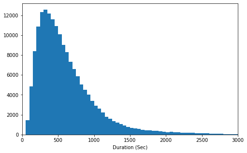

```python
# start with a standard-scaled plot of the duration_sec column
binsize = 50
bins = np.arange(50, df['duration_sec'].max()+binsize, binsize)

plt.figure(figsize=[8, 5])
plt.hist(data = df, x = 'duration_sec', bins=bins)
plt.xlabel('Duration (Sec)')
plt.xlim([0, 3000]);
```

This is a right-skewed distribution with a very long tail. this distribution should be scaled for more accurate figure

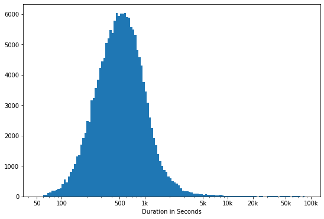

```python
# there's a long tail in the distribution, so it is plotted on a log scale
log_binsize = 0.025
bins = 10 ** np.arange(1.7, np.log10(df['duration_sec'].max())+log_binsize, log_binsize)

plt.figure(figsize=[9, 6])
plt.hist(data = df, x = 'duration_sec', bins=bins)
plt.xscale('log')
plt.xticks([50, 1e2, 5e2, 1e3, 5e3, 1e4, 2e4, 5e4, 1e5], [50, '100', '500', '1k', '5k', '10k', '20k', '50k', '100k'])
plt.xlabel('Duration in Seconds');
```

The distribution shows that a lot of trips are on the short duration end (200 - 1500 secs) and fewer trips occur on the long duration end.

1. **Frequency of trips taken per day in a week**

```python
# First, I convert day, and hour into ordered categorical types so i can plot a bar chart
converted = {'start_day': ['Monday','Tuesday','Wednesday','Thursday','Friday', 'Saturday', 'Sunday'],
                    'end_day': ['Monday','Tuesday','Wednesday','Thursday','Friday', 'Saturday', 'Sunday'],
                   'start_hr': [str(i) for i in range(0,24)],
                   'end_hr': [str(i) for i in range(0,24)]}

for var in converted:
    ordered_var = pd.api.types.CategoricalDtype(ordered = True,
                                                categories = converted[var])
    df[var] = df[var].astype(ordered_var)
```

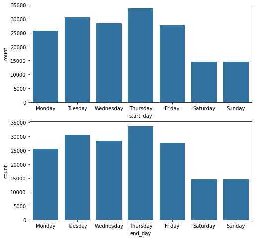

```python
#Then I plot number of rides per day with seaborn
# ride frequency per days with start and end days as subplots

fig, ax = plt.subplots(2, figsize = [8,8])

default_color = sb.color_palette()[0]
sb.countplot(data = df, x = 'start_day', color = default_color,  ax = ax[0])
sb.countplot(data = df, x = 'end_day', color = default_color,  ax = ax[1])
```

I can see that the subplots are the same as the values are consistent .

1. **How old are the riders of these bikes?**

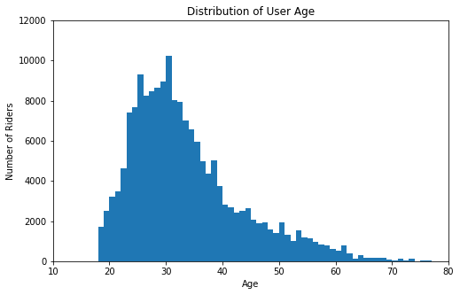

```python
# Plotting age distribution derived from member's birth year.
binsize = 1
bins = np.arange(0, df['member_birth_year'].astype(float).max()+binsize, binsize)

plt.figure(figsize=[8, 5])
plt.hist(data = df.dropna(), x = 'member_birth_year', bins = bins)
plt.axis([1939, 2009, 0, 12000])
plt.xticks([1939, 1949, 1959, 1969, 1979, 1989, 1999, 2009], [(2019-1939), (2019-1949), (2019-1959), (2019-1969), (2019-1979), (2019-1989), (2019-1999), (2019-2009)])
plt.gca().invert_xaxis()
plt.title('Distribution of User Age')
plt.xlabel('Age')
plt.ylabel('Number of Riders')
plt.show()
```

How old are the riders of these bikes?

According to the age distribution above, It can be seen that most of the riders are aged between 20 to 40 years old.

When investigating the Birth year variables to ascertain age, Birth year column is transformed by substracting the year from current year in order to give the distibution for age more accurately.

1. **What is the Distribution of the User types in this data**

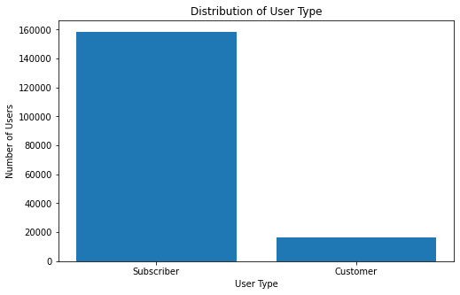

```python
# plotting types of users in this dataset
plt.figure(figsize=[8,5])
plt.bar(x = df.user_type.value_counts().keys(), height = df.user_type.value_counts() )
plt.title('Distribution of User Type')
plt.xlabel('User Type')
plt.ylabel('Number of Users')
plt.show()
```

For User type, It can be seen that most of the riders (users) are subscibers to the Go-Ford Bike System with about 160k while only a few (around 20k) are customers.

**5. More Men or Women? Distribution of Gender**

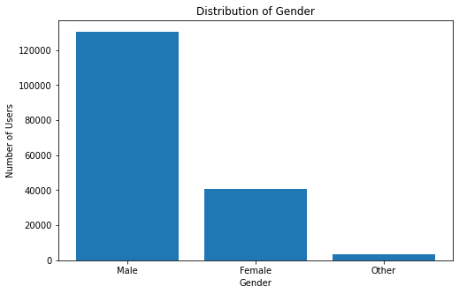

```python
# plotting the gender chart of the dataset
plt.figure(figsize=[8,5])
plt.bar(x = df.member_gender.value_counts().keys(), height = df.member_gender.value_counts() )
plt.title('Distribution of Gender')
plt.xlabel('Gender')
plt.ylabel('Number of Users')
plt.show()
```

For Gender type of Users, It can be seen that majority of the riders (users) are Men (male)with about 120k while there are fewer women (female) with around 40k. The rest are categorized as others.

# **BIVARIATE DATA EXPLORATION**

1. **What is the relationship between Trip Duration and Age**

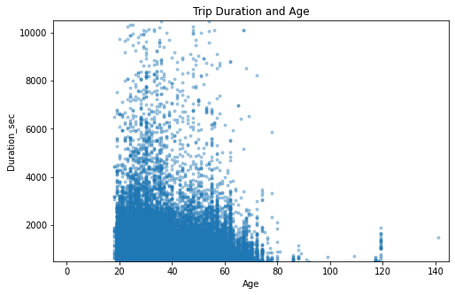

```python
#Plotting relationship distribution between trip duration and age
plt.figure(figsize=[8,5])
plt.scatter((2019 - df['member_birth_year']), df['duration_sec'], alpha = 0.35, marker = '.' )
plt.axis([-5, 145, 500, 10500])
plt.title('Trip Duration and Age')
plt.xlabel('Age')
plt.ylabel('Duration_sec')
plt.show()
```

It is difficult to deduce from this graph so I will crop it out from 20 years old to 80 years old where most of the entries occur (below 6000 seconds)

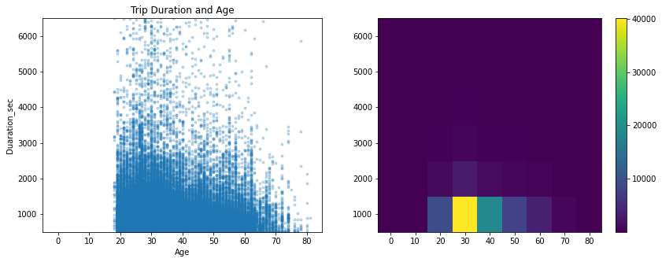

```python
# Crop the figure to entries below 600 and age between 20 and 80.

plt.figure(figsize=[14,5])

plt.subplot(1, 2, 1)
plt.scatter((2019 - df['member_birth_year']), df['duration_sec'], alpha = 0.25, marker = '.' )
plt.axis([-5, 85, 500, 6500])
plt.title('Trip Duration and Age')
plt.xlabel('Age')
plt.ylabel('Duaration_sec')

#Polt a colorplot to see better the age of users
plt.subplot(1, 2, 2)
bins_y = np.arange(500, 6500+1, 1000)
bins_x = np.arange(-5, 85+1, 10)
plt.hist2d((2019 - df['member_birth_year']), df['duration_sec'],
           bins = [bins_x, bins_y])
plt.colorbar(ticks=[10000, 20000, 30000, 40000]);
plt.show()
```

According to the chart above, It can be seen that most recorded users are aged between 20 and 45. Therfore, most trip duration is registered by younger users.

1. **What is the relationship between bike_share_for_all_trip and Customer type**

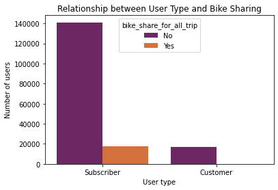

```python
#plotting chart for user_type vs bike_share_for_all_trip
plt.plot(3, 1, 1)
sb.countplot(data = df, x = 'user_type', hue = 'bike_share_for_all_trip', order=df.user_type.value_counts().index,
             palette = 'inferno')
plt.title('Relationship between User Type and Bike Sharing')
plt.xlabel('User type')
plt.ylabel('Number of users')
plt.show()
```

In the figure above, it can be seen that only Subscribers enage in bike-sharing. This may be because customers dont have access to the feature.

Only a small percentage of subscribers share bikes.

1. **What is the relationship between User_type and Gender**

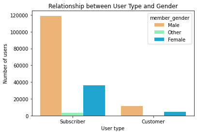

```python
#plotting  chart for user_type vs Gender
ax = plt.plot(3, 1, 3)
sb.countplot(data = df, x = 'user_type', hue = 'member_gender',order=df.user_type.value_counts().index,
             palette = 'rainbow_r')
plt.title('Relationship between User Type and Gender')
plt.xlabel('User type')
plt.ylabel('Number of users')
plt.show()
```

1. **What is the Relationship between start_day and user_type**

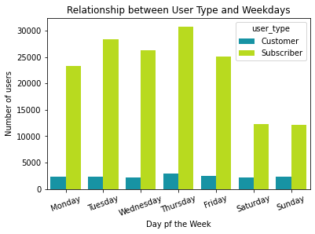

```python
##plotting  chart for start_day vs user_type
ax = plt.plot(3, 1, 2)
sb.countplot(data = df, x = 'start_day', hue = 'user_type', palette = 'nipy_spectral')
plt.xticks(rotation=20)
plt.title('Relationship between User Type and Weekdays')
plt.xlabel('Day pf the Week')
plt.ylabel('Number of users')

plt.show()
```

1. **what is the relationship between trip duration and start&end stations**

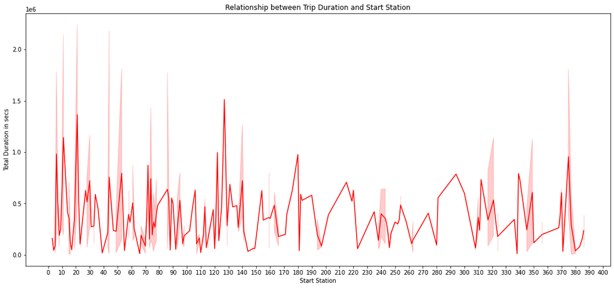

```python
#plotting for the Trip_duration and start Station
S = []

all_start_station_ids = sorted(df.start_station_id.unique())
for x in all_start_station_ids :
    S.append(df[df.start_station_id == x].duration_sec.sum())
total_duration = pd.Series(S)

plt.figure(figsize = [18, 8])
sb.lineplot(x = df['start_station_id'], y = total_duration, color='red')
plt.xticks(range(0, 401, 10))
plt.title('Relationship between Trip Duration and Start Station')
plt.xlabel('Start Station')
plt.ylabel('Total Duration in secs')
plt.show()
```

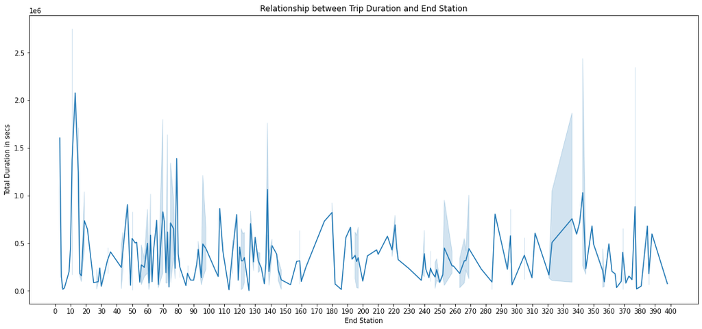

```python
#plotting for the Trip_duration and End Station
E = []

all_end_station_ids = sorted(df.end_station_id.unique())
for x in all_end_station_ids :
    E.append(df[df.end_station_id == x].duration_sec.sum())
total_duration = pd.Series(E)

plt.figure(figsize = [18, 8])
sb.lineplot(x = df['end_station_id'], y = total_duration)
plt.xticks(range(0, 401, 10))
plt.title('Relationship between Trip Duration and End Station')
plt.xlabel('End Station')
plt.ylabel('Total Duration in secs')
plt.show()
```

For the Relationship between Trip Duration and Start_Station and End_Station.

It can be seen that trip duration for some stations are higher and for some stations for end station is higher. as a result, we can see that what stations result in starting of longer trips and what stations comes end of longer trips.

1. **What is the relationship between Trip Duration and Gender**

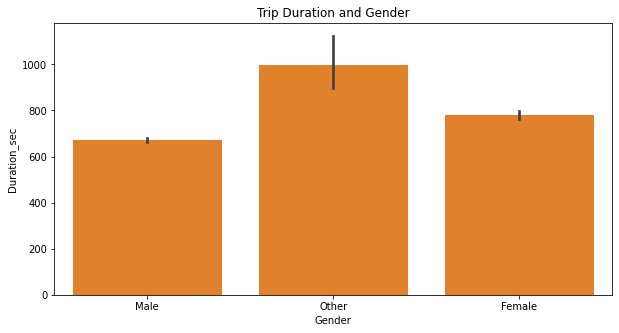

```python
plt.figure(figsize = [10, 5])
base_color = sb.color_palette()[1]
sb.barplot(data = df, x = 'member_gender', y = 'duration_sec', color = base_color)
plt.title('Trip Duration and Gender')
plt.xlabel('Gender')
plt.ylabel('Duration_sec')
plt.show()
```

For the relationship between Trip Duration and Gender, It can be seen that Other Gender take longer trips; followed by women while the Men take the shortest trips.

**12. What is the relationship between Trip Duration and User Type**

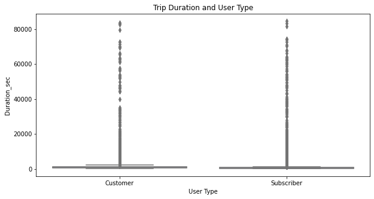

```python
#plotting boxplot for bivariate relationship between two columns user_type and duration_sec
plt.figure(figsize = [10, 5])
base_color = sb.color_palette('Purples_r')[3]
sb.boxplot(data = df, x = 'user_type', y = 'duration_sec', color = base_color)
plt.title('Trip Duration and User Type')
plt.xlabel('User Type')
plt.ylabel('Duration_sec')
plt.show()
```

The values are very widespread to see a box plot, So I will to zoom the duration axis to 4000 seconds to get a more accurate chart.

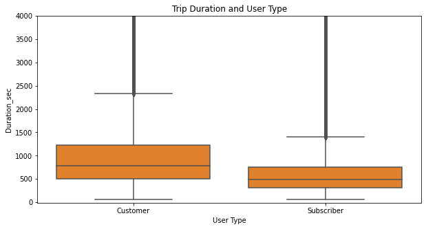

```python
#plotting scaled boxplot for bivariate relationship between two columns user_type and duration_sec
plt.figure(figsize = [10, 5])
base_color = sb.color_palette()[1]
sb.boxplot(data = df, x = 'user_type', y = 'duration_sec', color = base_color)
plt.ylim([-10, 4000])
plt.title('Trip Duration and User Type')
plt.xlabel('User Type')
plt.ylabel('Duration_sec')
plt.show()
```

For the relationship between Trip Duration and User Type, It can be seen that customers rides longer trips then subscribers. although it should be noted that the number of subscriber riders are very high when compared to the customer.

**13. What is the relationship between Trip Duration, Weekdays and User type**

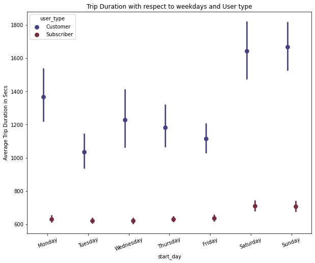

```python
fig = plt.figure(figsize = [10,8])
ax = sb.pointplot(data = df, x ='start_day', y = 'duration_sec', hue = 'user_type',
           palette = 'icefire', linestyles = '', dodge = 0.2)
plt.title('Trip Duration with respect to weekdays and User type')
plt.ylabel('Average Trip Duration in Secs')
plt.xticks(rotation=20)
ax.set_yticklabels([],minor = True)
plt.show();
```

**14. What is the relationship between Trip Duration, Gender and User type**

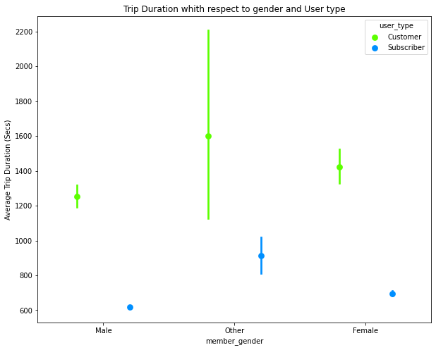

```python
fig = plt.figure(figsize = [10,8])
ax = sb.pointplot(data = df, x ='member_gender', y = 'duration_sec', hue = 'user_type',
           palette = 'gist_rainbow', linestyles = '', dodge = 0.4)
plt.title('Trip Duration whith respect to gender and User type')
plt.ylabel('Average Trip Duration (Secs)')
ax.set_yticklabels([],minor = True)
plt.show();
```

In the chart above, it can be seen that the other gender group spent the most time duration during rides. This is followed by female and the Male gender records the lowest trip duration.

This is true for both User types.

References:Resources Used

https://stackoverflow.com/

https://medium.com/@morganjonesartist/color-guide-to-seaborn-palettes-da849406d44f

https://seaborn.pydata.org/generated/seaborn.barplot.html

https://stackoverflow.com/questions/49554139/boxplot-of-multiple-columns-of-a-pandas-dataframe-on-the-same-figure-seaborn

https://github.com/nbalotaibi/Communicate-Data-Findings/blob/master/Exploration_Ford_GoBike.ipynb

https://www.codegrepper.com/code-examples/python/how+to+plot+using+seaborn+with+multiple+columns